# Mini-projet

Régis Gourdel

Wed Mar 8 15:42:26 2017

*Initialisation de l’environnement :*

```r
rm(list = ls())
load('absc-Val.Rdata')
source('fonctions-miniprojet.R')
source('mesfonctions.R')
```

**1.1**

On réalise une fonction pour tracer les polynômes d’interpolation quatre par quatre, les lignes de plus haut degré étant les plus foncées :

```r
neval = 1000
a = 2^(-16); b = 1.5
z = seq(a,b,length.out = neval)
y = evalBoiteNoire(z)
cols = c("red","orange","green","blue")

intpol = function(deg) {
    plot(z, y, type = 'l', col = 'black')
    for (i in 1:length(deg)) {
        x = seq(a, b, length.out = deg[i])
        f = interpolDividif(x, evalBoiteNoire(x), z)
        lines(z, f, col = cols[i], lty = 2)
    }
}
```

Au bas degré, de 2 à 5, on constate que l’interpolation suit assez mal la valeur réelle. Il n’y a donc pas encore de phénomène de Runge mais l’approximation semble assez grossière.

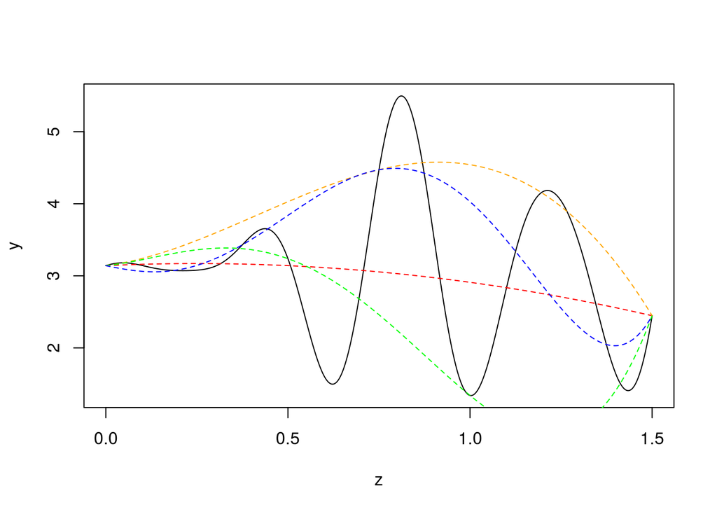

```r
intpol(c(2,3,4,5))
```

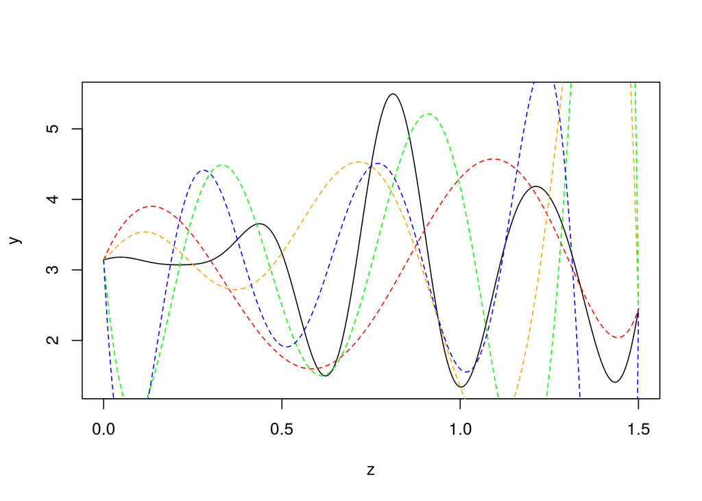

```r
intpol(c(6,7,8,9))
```

Pour des degré plus élevés, jusqu’au 30 ci-dessous, on constate que l’approximation est très fine au centre de l’intervalle mais le phénomène de Runge est très important sur les bords.

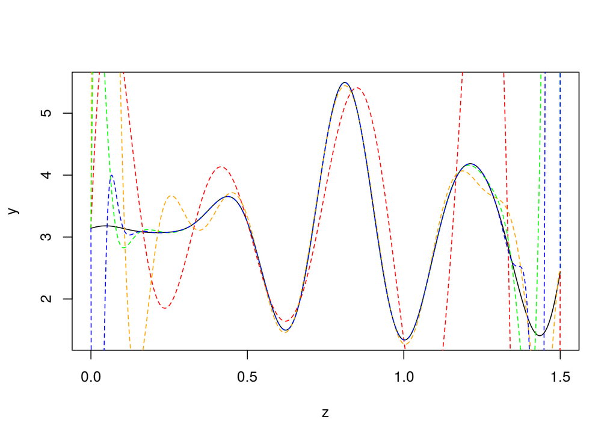

```r
intpol(c(10,15,20,30))
```

**1.2**

On crée une fonction qui réalise l’interpolation avec les points de Tchebychev :

```r
intpoltche = function(deg) {
    plot(z, y, type = 'l', col = 'black')
    for (i in 1:length(deg)) {
        m = deg[i]
        rtche = function(x) { cos((2*x - 1)*pi/2/m) }
        x = rtche(seq(1:m)) * (b - a)/2 + (a + b)/2
        f = interpolDividif(x, evalBoiteNoire(x), z)
        lines(z, f, col = cols[i], lty = 2)
    }
}
```

Pour des degrés inférieurs à 18 l’approximation s’améliore mais n’est pas encore très fine :

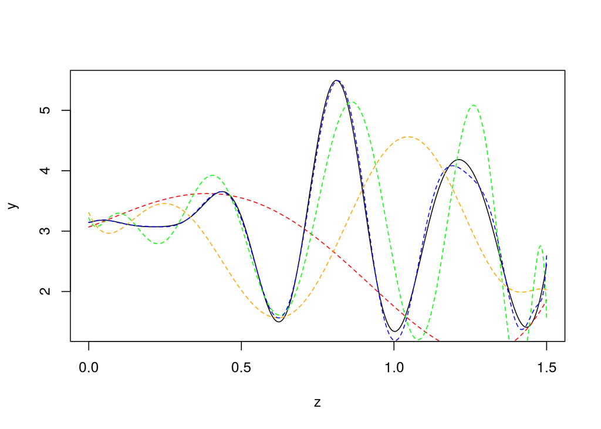

```r
intpoltche(c(4,8,12,18))
```

On arrive alors sur une plage de degrés, de 20 à 42, que l’on pourra qualifier de raisonnables, et qui fournissent une bonne approximation de la fonction :

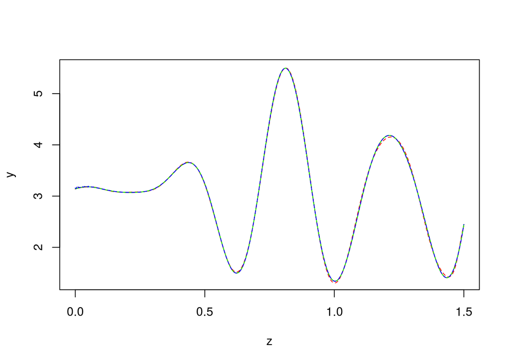

```r
intpoltche(c(20,26,34,42))
```

Puis à partir du degré 43 on observe un phénomène de Runge dont l’effet s’accentue pour les degrés encore supérieurs :

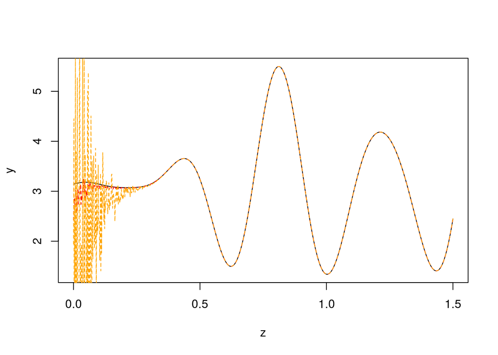

```r
intpoltche(c(43,47))
```

**1.3.a**

On emploie une version simplifié de la fonction piecewiseInterpolation réalisée dans le TD2.

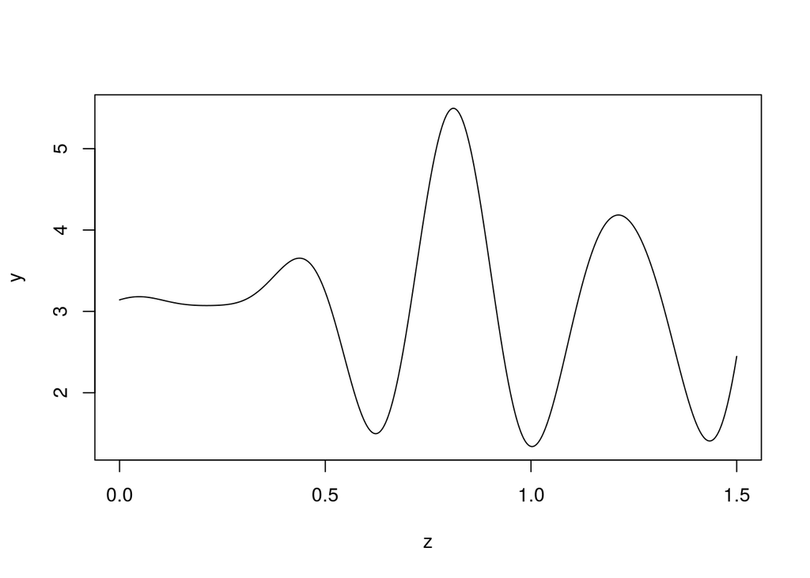

```r
piecewiseItp = function(n, M){
  intEndPoints = seq(a, b, length.out = M + 1)
  f = c(); z = c()
  x = seq(-1,1,length.out = n)
  nevalp = (neval / M) + 1
  for (m in 1:M){
    A = intEndPoints[m]; B = intEndPoints[m + 1]
    xm = x * (B - A)/2 + (A + B)/2
    zm = seq(A, B, length.out = nevalp)
    fm = interpolDividif(xm, evalBoiteNoire(xm), zm)
    if(m >= 2){
      ## remove first element of zm, fm to avoid duplicate values of the  interpolating vector
      zm = zm[2:nevalp]
      fm = fm[2:nevalp]
    }
    z = c(z,zm)
    f = c(f,fm)
  }
  return(rbind(f,z))
}

M = 10
plot(z, y, type = 'l', col = 'black')
for (i in 1:3) {
  temp = piecewiseItp(i, M)
  yy = temp[1]; zz = temp[2]
  lines(zz, yy, col = cols[i], lty = 2)
}
```